# Capstone Project

Zakka

8/12/2021

## Case Study: How Does a Bike-Share Navigate Speedy Success?

This is the capstone project from Google Data Analytics Professional Certification Course on Coursera.

### Scenario

You are a junior data analyst working in the marketing analyst team at Cyclistic, a bike-share company in Chicago. The director of marketing believes the company’s future success depends on maximizing the number of annual memberships. Therefore, your team wants to understand how casual riders and annual members use Cyclistic bikes differently. From these insights, your team will design a new marketing strategy to convert casual riders into annual members. But first, Cyclistic executives must approve your recommendations, so they must be backed up with compelling data insights and professional data visualizations.

### Characters and teams

- **Cyclistic**: A bike-share program that features more than 5,800 bicycles and 600 docking stations. Cyclistic sets itself apart by also offering reclining bikes, hand tricycles, and cargo bikes, making bike-share more inclusive to people with disabilities and riders who can’t use a standard two-wheeled bike. The majority of riders opt for traditional bikes; about 8% of riders use the assistive options. Cyclistic users are more likely to ride for leisure, but about 30% use them to commute to work each day.
- **Lily Moreno**: The director of marketing and your manager. Moreno is responsible for the development of campaigns and initiatives to promote the bike-share program. These may include email, social media, and other channels.
- **Cyclistic marketing analytics team**: A team of data analysts who are responsible for collecting, analyzing, and reporting data that helps guide Cyclistic marketing strategy. You joined this team six months ago and have been busy learning about Cyclistic’s mission and business goals — as well as how you, as a junior data analyst, can help Cyclistic achieve them.
- **Cyclistic executive team**: The notoriously detail-oriented executive team will decide whether to approve the recommended marketing program

### About the company

In 2016, Cyclistic launched a successful bike-share offering. Since then, the program has grown to a fleet of 5,824 bicycles that are geotracked and locked into a network of 692 stations across Chicago. The bikes can be unlocked from one station and returned to any other station in the system anytime.

Until now, Cyclistic’s marketing strategy relied on building general awareness and appealing to broad consumer segments. One approach that helped make these things possible was the flexibility of its pricing plans: single-ride passes, full-day passes, and annual memberships. Customers who purchase single-ride or full-day passes are referred to as casual riders. Customers who purchase annual memberships are Cyclistic members.

Cyclistic’s finance analysts have concluded that annual members are much more profitable than casual riders. Although the pricing flexibility helps Cyclistic attract more customers, Moreno believes that maximizing the number of annual members will be key to future growth. Rather than creating a marketing campaign that targets all-new customers, Moreno believes there is a very good chance to convert casual riders into members. She notes that casual riders are already aware of the Cyclistic program and have chosen Cyclistic for their mobility needs.

Moreno has set a clear goal: Design marketing strategies aimed at converting casual riders into annual members. In order to do that, however, the marketing analyst team needs to better understand how annual members and casual riders differ, why casual riders would buy a membership, and how digital media could affect their marketing tactics. Moreno and her team are interested in analyzing the Cyclistic historical bike trip data to identify trends.

### Data Analysis Steps

1. Ask
2. Prepare
3. Process
4. Analyze
5. Share
6. Act

#### Ask

In this step, I have to understand the business goal from this analysis. From that, I can identify the business task.

The business task is: *How to increase the conversion of casual riders into members?*

#### Prepare

The data used in this project can be accessed from [here](https://divvy-tripdata.s3.amazonaws.com/index.html)

This data came from a reliable source and fulfill the ROCCC condition for a good data (Reliable, Original, Comprehensive, Current, and Cited)

The dataset organized as .csv file, divided by each month, from April 2020 to April 2021.

#### Process

The tool that I used is R.

##### Import required library

```r
#Import required library

library(tidyverse)  #helps wrangle data
library(lubridate)  #helps wrangle date attributes
```

```r
library(ggplot2)  #helps visualize data
library(skimr)
library(Hmisc)
getwd() #displays your working directory
```

```
## [1] "D:/Studi/Belajar Mandiri/Coursera/Google DA/capstone/202010-divvy-tripdata"
```

```r
setwd("D:/Studi/Belajar Mandiri/Coursera/Google DA/capstone/202010-divvy-tripdata")
```

##### Collect data

```r
data_202004 <- read_csv("202004-divvy-tripdata.csv")
data_202005 <- read_csv("202005-divvy-tripdata.csv")
data_202006 <- read_csv("202006-divvy-tripdata.csv")
data_202007 <- read_csv("202007-divvy-tripdata.csv")
data_202008 <- read_csv("202008-divvy-tripdata.csv")
data_202009 <- read_csv("202009-divvy-tripdata.csv")
data_202010 <- read_csv("202010-divvy-tripdata.csv")
data_202011 <- read_csv("202011-divvy-tripdata.csv")
data_202012 <- read_csv("202012-divvy-tripdata.csv")
data_202101 <- read_csv("202101-divvy-tripdata.csv")
data_202102 <- read_csv("202102-divvy-tripdata.csv")
data_202103 <- read_csv("202103-divvy-tripdata.csv")
data_202104 <- read_csv("202104-divvy-tripdata.csv")
```

##### Wrange data and combine into a single file

```r
#Compare column names each of the files

colnames(data_202004)
```

```
##  [1] "ride_id"            "rideable_type"      "started_at"
##  [4] "ended_at"           "start_station_name" "start_station_id"
##  [7] "end_station_name"   "end_station_id"     "start_lat"
## [10] "start_lng"          "end_lat"            "end_lng"
## [13] "member_casual"
```

```r
colnames(data_202005)
```

```
##  [1] "ride_id"            "rideable_type"      "started_at"
##  [4] "ended_at"           "start_station_name" "start_station_id"
##  [7] "end_station_name"   "end_station_id"     "start_lat"
## [10] "start_lng"          "end_lat"            "end_lng"
## [13] "member_casual"
```

```r
colnames(data_202006)
```

```
##  [1] "ride_id"            "rideable_type"      "started_at"
##  [4] "ended_at"           "start_station_name" "start_station_id"
##  [7] "end_station_name"   "end_station_id"     "start_lat"
## [10] "start_lng"          "end_lat"            "end_lng"
## [13] "member_casual"
```

```r
colnames(data_202007)
```

```
##  [1] "ride_id"            "rideable_type"      "started_at"
##  [4] "ended_at"           "start_station_name" "start_station_id"
##  [7] "end_station_name"   "end_station_id"     "start_lat"
## [10] "start_lng"          "end_lat"            "end_lng"
## [13] "member_casual"
```

```r
colnames(data_202008)
```

```
##  [1] "ride_id"            "rideable_type"      "started_at"
##  [4] "ended_at"           "start_station_name" "start_station_id"
##  [7] "end_station_name"   "end_station_id"     "start_lat"
## [10] "start_lng"          "end_lat"            "end_lng"
## [13] "member_casual"
```

```r
colnames(data_202009)
```

```
##  [1] "ride_id"            "rideable_type"      "started_at"
##  [4] "ended_at"           "start_station_name" "start_station_id"
##  [7] "end_station_name"   "end_station_id"     "start_lat"
## [10] "start_lng"          "end_lat"            "end_lng"
## [13] "member_casual"
```

```r
colnames(data_202010)
```

```
##  [1] "ride_id"            "rideable_type"      "started_at"
##  [4] "ended_at"           "start_station_name" "start_station_id"
##  [7] "end_station_name"   "end_station_id"     "start_lat"
## [10] "start_lng"          "end_lat"            "end_lng"
## [13] "member_casual"
```

```r
colnames(data_202011)
```

```
##  [1] "ride_id"            "rideable_type"      "started_at"
##  [4] "ended_at"           "start_station_name" "start_station_id"
##  [7] "end_station_name"   "end_station_id"     "start_lat"
## [10] "start_lng"          "end_lat"            "end_lng"
## [13] "member_casual"
```

```r
colnames(data_202012)
```

```
##  [1] "ride_id"            "rideable_type"      "started_at"
##  [4] "ended_at"           "start_station_name" "start_station_id"
##  [7] "end_station_name"   "end_station_id"     "start_lat"
## [10] "start_lng"          "end_lat"            "end_lng"
## [13] "member_casual"
```

```r
colnames(data_202101)
```

```
##  [1] "ride_id"            "rideable_type"      "started_at"
##  [4] "ended_at"           "start_station_name" "start_station_id"
##  [7] "end_station_name"   "end_station_id"     "start_lat"
## [10] "start_lng"          "end_lat"            "end_lng"
## [13] "member_casual"
```

```r
colnames(data_202102)
```

```
##  [1] "ride_id"            "rideable_type"      "started_at"
##  [4] "ended_at"           "start_station_name" "start_station_id"
##  [7] "end_station_name"   "end_station_id"     "start_lat"
## [10] "start_lng"          "end_lat"            "end_lng"
## [13] "member_casual"
```

```r
colnames(data_202103)
```

```
##  [1] "ride_id"            "rideable_type"      "started_at"
##  [4] "ended_at"           "start_station_name" "start_station_id"
##  [7] "end_station_name"   "end_station_id"     "start_lat"
## [10] "start_lng"          "end_lat"            "end_lng"
## [13] "member_casual"
```

```r
colnames(data_202104)
```

```
##  [1] "ride_id"            "rideable_type"      "started_at"
##  [4] "ended_at"           "start_station_name" "start_station_id"
##  [7] "end_station_name"   "end_station_id"     "start_lat"
## [10] "start_lng"          "end_lat"            "end_lng"
## [13] "member_casual"
```

The column names from all of the data are the same, now it’s time to inspect the dataset and look for incongruencies.

```r
str(data_202004)
```

```
## spec_tbl_df [84,776 x 13] (S3: spec_tbl_df/tbl_df/tbl/data.frame)
##  $ ride_id           : chr [1:84776] "A847FADBBC638E45" "5405B80E996FF60D" "5DD24A79A4E006F4" "2A59BBDF5CDBA725" ...
##  $ rideable_type     : chr [1:84776] "docked_bike" "docked_bike" "docked_bike" "docked_bike" ...
##  $ started_at        : POSIXct[1:84776], format: "2020-04-26 17:45:14" "2020-04-17 17:08:54" ...
##  $ ended_at          : POSIXct[1:84776], format: "2020-04-26 18:12:03" "2020-04-17 17:17:03" ...
##  $ start_station_name: chr [1:84776] "Eckhart Park" "Drake Ave & Fullerton Ave" "McClurg Ct & Erie St" "California Ave & Division St" ...
##  $ start_station_id  : num [1:84776] 86 503 142 216 125 173 35 434 627 377 ...
##  $ end_station_name  : chr [1:84776] "Lincoln Ave & Diversey Pkwy" "Kosciuszko Park" "Indiana Ave & Roosevelt Rd" "Wood St & Augusta Blvd" ...
##  $ end_station_id    : num [1:84776] 152 499 255 657 323 35 635 382 359 508 ...
##  $ start_lat         : num [1:84776] 41.9 41.9 41.9 41.9 41.9 ...
##  $ start_lng         : num [1:84776] -87.7 -87.7 -87.6 -87.7 -87.6 ...
##  $ end_lat           : num [1:84776] 41.9 41.9 41.9 41.9 42 ...
##  $ end_lng           : num [1:84776] -87.7 -87.7 -87.6 -87.7 -87.7 ...
##  $ member_casual     : chr [1:84776] "member" "member" "member" "member" ...
##  - attr(*, "spec")=
##   .. cols(
##   ..   ride_id = col_character(),
##   ..   rideable_type = col_character(),
##   ..   started_at = col_datetime(format = ""),
##   ..   ended_at = col_datetime(format = ""),
##   ..   start_station_name = col_character(),
##   ..   start_station_id = col_double(),
##   ..   end_station_name = col_character(),
##   ..   end_station_id = col_double(),
##   ..   start_lat = col_double(),
##   ..   start_lng = col_double(),
##   ..   end_lat = col_double(),
##   ..   end_lng = col_double(),
##   ..   member_casual = col_character()
##   .. )
```

```r
str(data_202005)
```

```
## spec_tbl_df [200,274 x 13] (S3: spec_tbl_df/tbl_df/tbl/data.frame)
##  $ ride_id           : chr [1:200274] "02668AD35674B983" "7A50CCAF1EDDB28F" "2FFCDFDB91FE9A52" "58991CF1DB75BA84" ...
##  $ rideable_type     : chr [1:200274] "docked_bike" "docked_bike" "docked_bike" "docked_bike" ...
##  $ started_at        : POSIXct[1:200274], format: "2020-05-27 10:03:52" "2020-05-25 10:47:11" ...
##  $ ended_at          : POSIXct[1:200274], format: "2020-05-27 10:16:49" "2020-05-25 11:05:40" ...
##  $ start_station_name: chr [1:200274] "Franklin St & Jackson Blvd" "Clark St & Wrightwood Ave" "Kedzie Ave & Milwaukee Ave" "Clarendon Ave & Leland Ave" ...
##  $ start_station_id  : num [1:200274] 36 340 260 251 261 206 261 180 331 219 ...
##  $ end_station_name  : chr [1:200274] "Wabash Ave & Grand Ave" "Clark St & Leland Ave" "Kedzie Ave & Milwaukee Ave" "Lake Shore Dr & Wellington Ave" ...
##  $ end_station_id    : num [1:200274] 199 326 260 157 206 22 261 180 300 305 ...
##  $ start_lat         : num [1:200274] 41.9 41.9 41.9 42 41.9 ...
##  $ start_lng         : num [1:200274] -87.6 -87.6 -87.7 -87.7 -87.7 ...
##  $ end_lat           : num [1:200274] 41.9 42 41.9 41.9 41.8 ...
##  $ end_lng           : num [1:200274] -87.6 -87.7 -87.7 -87.6 -87.6 ...
##  $ member_casual     : chr [1:200274] "member" "casual" "casual" "casual" ...
##  - attr(*, "spec")=
##   .. cols(
##   ..   ride_id = col_character(),
##   ..   rideable_type = col_character(),
##   ..   started_at = col_datetime(format = ""),
##   ..   ended_at = col_datetime(format = ""),
##   ..   start_station_name = col_character(),
##   ..   start_station_id = col_double(),
##   ..   end_station_name = col_character(),
##   ..   end_station_id = col_double(),
##   ..   start_lat = col_double(),
##   ..   start_lng = col_double(),
##   ..   end_lat = col_double(),
##   ..   end_lng = col_double(),
##   ..   member_casual = col_character()
##   .. )
```

```r
str(data_202006)
```

```
## spec_tbl_df [343,005 x 13] (S3: spec_tbl_df/tbl_df/tbl/data.frame)
##  $ ride_id           : chr [1:343005] "8CD5DE2C2B6C4CFC" "9A191EB2C751D85D" "F37D14B0B5659BCF" "C41237B506E85FA1" ...
##  $ rideable_type     : chr [1:343005] "docked_bike" "docked_bike" "docked_bike" "docked_bike" ...
##  $ started_at        : POSIXct[1:343005], format: "2020-06-13 23:24:48" "2020-06-26 07:26:10" ...
##  $ ended_at          : POSIXct[1:343005], format: "2020-06-13 23:36:55" "2020-06-26 07:31:58" ...
##  $ start_station_name: chr [1:343005] "Wilton Ave & Belmont Ave" "Federal St & Polk St" "Daley Center Plaza" "Broadway & Cornelia Ave" ...
##  $ start_station_id  : num [1:343005] 117 41 81 303 327 327 41 115 338 84 ...
##  $ end_station_name  : chr [1:343005] "Damen Ave & Clybourn Ave" "Daley Center Plaza" "State St & Harrison St" "Broadway & Berwyn Ave" ...
##  $ end_station_id    : num [1:343005] 163 81 5 294 117 117 81 303 164 53 ...
##  $ start_lat         : num [1:343005] 41.9 41.9 41.9 41.9 41.9 ...
##  $ start_lng         : num [1:343005] -87.7 -87.6 -87.6 -87.6 -87.7 ...
##  $ end_lat           : num [1:343005] 41.9 41.9 41.9 42 41.9 ...
##  $ end_lng           : num [1:343005] -87.7 -87.6 -87.6 -87.7 -87.7 ...
##  $ member_casual     : chr [1:343005] "casual" "member" "member" "casual" ...
##  - attr(*, "spec")=
##   .. cols(
##   ..   ride_id = col_character(),
##   ..   rideable_type = col_character(),
##   ..   started_at = col_datetime(format = ""),
##   ..   ended_at = col_datetime(format = ""),
##   ..   start_station_name = col_character(),
##   ..   start_station_id = col_double(),
##   ..   end_station_name = col_character(),
##   ..   end_station_id = col_double(),
##   ..   start_lat = col_double(),
##   ..   start_lng = col_double(),
##   ..   end_lat = col_double(),
##   ..   end_lng = col_double(),
##   ..   member_casual = col_character()
##   .. )
```

```r
str(data_202007)
```

```
## spec_tbl_df [551,480 x 13] (S3: spec_tbl_df/tbl_df/tbl/data.frame)
##  $ ride_id           : chr [1:551480] "762198876D69004D" "BEC9C9FBA0D4CF1B" "D2FD8EA432C77EC1" "54AE594E20B35881" ...
##  $ rideable_type     : chr [1:551480] "docked_bike" "docked_bike" "docked_bike" "docked_bike" ...
##  $ started_at        : POSIXct[1:551480], format: "2020-07-09 15:22:02" "2020-07-24 23:56:30" ...
##  $ ended_at          : POSIXct[1:551480], format: "2020-07-09 15:25:52" "2020-07-25 00:20:17" ...
##  $ start_station_name: chr [1:551480] "Ritchie Ct & Banks St" "Halsted St & Roscoe St" "Lake Shore Dr & Diversey Pkwy" "LaSalle St & Illinois St" ...
##  $ start_station_id  : num [1:551480] 180 299 329 181 268 635 113 211 176 31 ...
##  $ end_station_name  : chr [1:551480] "Wells St & Evergreen Ave" "Broadway & Ridge Ave" "Clark St & Wellington Ave" "Clark St & Armitage Ave" ...
##  $ end_station_id    : num [1:551480] 291 461 156 94 301 289 140 31 191 142 ...
##  $ start_lat         : num [1:551480] 41.9 41.9 41.9 41.9 41.9 ...
##  $ start_lng         : num [1:551480] -87.6 -87.6 -87.6 -87.6 -87.6 ...
##  $ end_lat           : num [1:551480] 41.9 42 41.9 41.9 41.9 ...
##  $ end_lng           : num [1:551480] -87.6 -87.7 -87.6 -87.6 -87.6 ...
##  $ member_casual     : chr [1:551480] "member" "member" "casual" "casual" ...
##  - attr(*, "spec")=
##   .. cols(
##   ..   ride_id = col_character(),
##   ..   rideable_type = col_character(),
##   ..   started_at = col_datetime(format = ""),
##   ..   ended_at = col_datetime(format = ""),
##   ..   start_station_name = col_character(),
##   ..   start_station_id = col_double(),
##   ..   end_station_name = col_character(),
##   ..   end_station_id = col_double(),
##   ..   start_lat = col_double(),
##   ..   start_lng = col_double(),
##   ..   end_lat = col_double(),
##   ..   end_lng = col_double(),
##   ..   member_casual = col_character()
##   .. )
```

```r
str(data_202008)
```

```
## spec_tbl_df [622,361 x 13] (S3: spec_tbl_df/tbl_df/tbl/data.frame)
##  $ ride_id           : chr [1:622361] "322BD23D287743ED" "2A3AEF1AB9054D8B" "67DC1D133E8B5816" "C79FBBD412E578A7" ...
##  $ rideable_type     : chr [1:622361] "docked_bike" "electric_bike" "electric_bike" "electric_bike" ...
##  $ started_at        : POSIXct[1:622361], format: "2020-08-20 18:08:14" "2020-08-27 18:46:04" ...
##  $ ended_at          : POSIXct[1:622361], format: "2020-08-20 18:17:51" "2020-08-27 19:54:51" ...
##  $ start_station_name: chr [1:622361] "Lake Shore Dr & Diversey Pkwy" "Michigan Ave & 14th St" "Columbus Dr & Randolph St" "Daley Center Plaza" ...
##  $ start_station_id  : num [1:622361] 329 168 195 81 658 658 196 67 153 177 ...
##  $ end_station_name  : chr [1:622361] "Clark St & Lincoln Ave" "Michigan Ave & 14th St" "State St & Randolph St" "State St & Kinzie St" ...
##  $ end_station_id    : num [1:622361] 141 168 44 47 658 658 49 229 225 305 ...
##  $ start_lat         : num [1:622361] 41.9 41.9 41.9 41.9 41.9 ...
##  $ start_lng         : num [1:622361] -87.6 -87.6 -87.6 -87.6 -87.7 ...
##  $ end_lat           : num [1:622361] 41.9 41.9 41.9 41.9 41.9 ...
##  $ end_lng           : num [1:622361] -87.6 -87.6 -87.6 -87.6 -87.7 ...
##  $ member_casual     : chr [1:622361] "member" "casual" "casual" "casual" ...
##  - attr(*, "spec")=
##   .. cols(
##   ..   ride_id = col_character(),
##   ..   rideable_type = col_character(),
##   ..   started_at = col_datetime(format = ""),
##   ..   ended_at = col_datetime(format = ""),
##   ..   start_station_name = col_character(),
##   ..   start_station_id = col_double(),
##   ..   end_station_name = col_character(),
##   ..   end_station_id = col_double(),
##   ..   start_lat = col_double(),
##   ..   start_lng = col_double(),
##   ..   end_lat = col_double(),
##   ..   end_lng = col_double(),
##   ..   member_casual = col_character()
##   .. )
```

```r
str(data_202009)
```

```
## spec_tbl_df [532,958 x 13] (S3: spec_tbl_df/tbl_df/tbl/data.frame)
##  $ ride_id           : chr [1:532958] "2B22BD5F95FB2629" "A7FB70B4AFC6CAF2" "86057FA01BAC778E" "57F6DC9A153DB98C" ...
##  $ rideable_type     : chr [1:532958] "electric_bike" "electric_bike" "electric_bike" "electric_bike" ...
##  $ started_at        : POSIXct[1:532958], format: "2020-09-17 14:27:11" "2020-09-17 15:07:31" ...
##  $ ended_at          : POSIXct[1:532958], format: "2020-09-17 14:44:24" "2020-09-17 15:07:45" ...
##  $ start_station_name: chr [1:532958] "Michigan Ave & Lake St" "W Oakdale Ave & N Broadway" "W Oakdale Ave & N Broadway" "Ashland Ave & Belle Plaine Ave" ...
##  $ start_station_id  : num [1:532958] 52 NA NA 246 24 94 291 NA NA NA ...
##  $ end_station_name  : chr [1:532958] "Green St & Randolph St" "W Oakdale Ave & N Broadway" "W Oakdale Ave & N Broadway" "Montrose Harbor" ...
##  $ end_station_id    : num [1:532958] 112 NA NA 249 24 NA 256 NA NA NA ...
##  $ start_lat         : num [1:532958] 41.9 41.9 41.9 42 41.9 ...
##  $ start_lng         : num [1:532958] -87.6 -87.6 -87.6 -87.7 -87.6 ...
##  $ end_lat           : num [1:532958] 41.9 41.9 41.9 42 41.9 ...
##  $ end_lng           : num [1:532958] -87.6 -87.6 -87.6 -87.6 -87.6 ...
##  $ member_casual     : chr [1:532958] "casual" "casual" "casual" "casual" ...
##  - attr(*, "spec")=
##   .. cols(
##   ..   ride_id = col_character(),
##   ..   rideable_type = col_character(),
##   ..   started_at = col_datetime(format = ""),
##   ..   ended_at = col_datetime(format = ""),
##   ..   start_station_name = col_character(),
##   ..   start_station_id = col_double(),
##   ..   end_station_name = col_character(),
##   ..   end_station_id = col_double(),
##   ..   start_lat = col_double(),
##   ..   start_lng = col_double(),
##   ..   end_lat = col_double(),
##   ..   end_lng = col_double(),
##   ..   member_casual = col_character()
##   .. )
```

```r
str(data_202010)
```

```
## spec_tbl_df [388,653 x 13] (S3: spec_tbl_df/tbl_df/tbl/data.frame)
##  $ ride_id           : chr [1:388653] "ACB6B40CF5B9044C" "DF450C72FD109C01" "B6396B54A15AC0DF" "44A4AEE261B9E854" ...
##  $ rideable_type     : chr [1:388653] "electric_bike" "electric_bike" "electric_bike" "electric_bike" ...
##  $ started_at        : POSIXct[1:388653], format: "2020-10-31 19:39:43" "2020-10-31 23:50:08" ...
##  $ ended_at          : POSIXct[1:388653], format: "2020-10-31 19:57:12" "2020-11-01 00:04:16" ...
##  $ start_station_name: chr [1:388653] "Lakeview Ave & Fullerton Pkwy" "Southport Ave & Waveland Ave" "Stony Island Ave & 67th St" "Clark St & Grace St" ...
##  $ start_station_id  : num [1:388653] 313 227 102 165 190 359 313 125 NA 174 ...
##  $ end_station_name  : chr [1:388653] "Rush St & Hubbard St" "Kedzie Ave & Milwaukee Ave" "University Ave & 57th St" "Broadway & Sheridan Rd" ...
##  $ end_station_id    : num [1:388653] 125 260 423 256 185 53 125 313 199 635 ...
##  $ start_lat         : num [1:388653] 41.9 41.9 41.8 42 41.9 ...
##  $ start_lng         : num [1:388653] -87.6 -87.7 -87.6 -87.7 -87.7 ...
##  $ end_lat           : num [1:388653] 41.9 41.9 41.8 42 41.9 ...
##  $ end_lng           : num [1:388653] -87.6 -87.7 -87.6 -87.7 -87.7 ...
##  $ member_casual     : chr [1:388653] "casual" "casual" "casual" "casual" ...
##  - attr(*, "spec")=
##   .. cols(
##   ..   ride_id = col_character(),
##   ..   rideable_type = col_character(),
##   ..   started_at = col_datetime(format = ""),
##   ..   ended_at = col_datetime(format = ""),
##   ..   start_station_name = col_character(),
##   ..   start_station_id = col_double(),
##   ..   end_station_name = col_character(),
##   ..   end_station_id = col_double(),
##   ..   start_lat = col_double(),
##   ..   start_lng = col_double(),
##   ..   end_lat = col_double(),
##   ..   end_lng = col_double(),
##   ..   member_casual = col_character()
##   .. )
```

```r
str(data_202011)
```

```
## spec_tbl_df [259,716 x 13] (S3: spec_tbl_df/tbl_df/tbl/data.frame)
##  $ ride_id           : chr [1:259716] "BD0A6FF6FFF9B921" "96A7A7A4BDE4F82D" "C61526D06582BDC5" "E533E89C32080B9E" ...
##  $ rideable_type     : chr [1:259716] "electric_bike" "electric_bike" "electric_bike" "electric_bike" ...
##  $ started_at        : POSIXct[1:259716], format: "2020-11-01 13:36:00" "2020-11-01 10:03:26" ...
##  $ ended_at          : POSIXct[1:259716], format: "2020-11-01 13:45:40" "2020-11-01 10:14:45" ...
##  $ start_station_name: chr [1:259716] "Dearborn St & Erie St" "Franklin St & Illinois St" "Lake Shore Dr & Monroe St" "Leavitt St & Chicago Ave" ...
##  $ start_station_id  : num [1:259716] 110 672 76 659 2 72 76 NA 58 394 ...
##  $ end_station_name  : chr [1:259716] "St. Clair St & Erie St" "Noble St & Milwaukee Ave" "Federal St & Polk St" "Stave St & Armitage Ave" ...
##  $ end_station_id    : num [1:259716] 211 29 41 185 2 76 72 NA 288 273 ...
##  $ start_lat         : num [1:259716] 41.9 41.9 41.9 41.9 41.9 ...
##  $ start_lng         : num [1:259716] -87.6 -87.6 -87.6 -87.7 -87.6 ...
##  $ end_lat           : num [1:259716] 41.9 41.9 41.9 41.9 41.9 ...
##  $ end_lng           : num [1:259716] -87.6 -87.7 -87.6 -87.7 -87.6 ...
##  $ member_casual     : chr [1:259716] "casual" "casual" "casual" "casual" ...
##  - attr(*, "spec")=
##   .. cols(
##   ..   ride_id = col_character(),
##   ..   rideable_type = col_character(),
##   ..   started_at = col_datetime(format = ""),
##   ..   ended_at = col_datetime(format = ""),
##   ..   start_station_name = col_character(),
##   ..   start_station_id = col_double(),
##   ..   end_station_name = col_character(),
##   ..   end_station_id = col_double(),
##   ..   start_lat = col_double(),
##   ..   start_lng = col_double(),
##   ..   end_lat = col_double(),
##   ..   end_lng = col_double(),
##   ..   member_casual = col_character()
##   .. )
```

```r
str(data_202012)
```

```
## spec_tbl_df [131,573 x 13] (S3: spec_tbl_df/tbl_df/tbl/data.frame)
##  $ ride_id           : chr [1:131573] "70B6A9A437D4C30D" "158A465D4E74C54A" "5262016E0F1F2F9A" "BE119628E44F871E" ...
##  $ rideable_type     : chr [1:131573] "classic_bike" "electric_bike" "electric_bike" "electric_bike" ...
##  $ started_at        : POSIXct[1:131573], format: "2020-12-27 12:44:29" "2020-12-18 17:37:15" ...
##  $ ended_at          : POSIXct[1:131573], format: "2020-12-27 12:55:06" "2020-12-18 17:44:19" ...
##  $ start_station_name: chr [1:131573] "Aberdeen St & Jackson Blvd" NA NA NA ...
##  $ start_station_id  : chr [1:131573] "13157" NA NA NA ...
##  $ end_station_name  : chr [1:131573] "Desplaines St & Kinzie St" NA NA NA ...
##  $ end_station_id    : chr [1:131573] "TA1306000003" NA NA NA ...
##  $ start_lat         : num [1:131573] 41.9 41.9 41.9 41.9 41.8 ...
##  $ start_lng         : num [1:131573] -87.7 -87.7 -87.7 -87.7 -87.6 ...
##  $ end_lat           : num [1:131573] 41.9 41.9 41.9 41.9 41.8 ...
##  $ end_lng           : num [1:131573] -87.6 -87.7 -87.7 -87.7 -87.6 ...
##  $ member_casual     : chr [1:131573] "member" "member" "member" "member" ...
##  - attr(*, "spec")=
##   .. cols(
##   ..   ride_id = col_character(),
##   ..   rideable_type = col_character(),
##   ..   started_at = col_datetime(format = ""),
##   ..   ended_at = col_datetime(format = ""),
##   ..   start_station_name = col_character(),
##   ..   start_station_id = col_character(),
##   ..   end_station_name = col_character(),
##   ..   end_station_id = col_character(),
##   ..   start_lat = col_double(),
##   ..   start_lng = col_double(),
##   ..   end_lat = col_double(),
##   ..   end_lng = col_double(),
##   ..   member_casual = col_character()
##   .. )
```

```r
str(data_202101)
```

```
## spec_tbl_df [96,834 x 13] (S3: spec_tbl_df/tbl_df/tbl/data.frame)
##  $ ride_id           : chr [1:96834] "E19E6F1B8D4C42ED" "DC88F20C2C55F27F" "EC45C94683FE3F27" "4FA453A75AE377DB" ...
##  $ rideable_type     : chr [1:96834] "electric_bike" "electric_bike" "electric_bike" "electric_bike" ...
##  $ started_at        : POSIXct[1:96834], format: "2021-01-23 16:14:19" "2021-01-27 18:43:08" ...
##  $ ended_at          : POSIXct[1:96834], format: "2021-01-23 16:24:44" "2021-01-27 18:47:12" ...
##  $ start_station_name: chr [1:96834] "California Ave & Cortez St" "California Ave & Cortez St" "California Ave & Cortez St" "California Ave & Cortez St" ...
##  $ start_station_id  : chr [1:96834] "17660" "17660" "17660" "17660" ...
##  $ end_station_name  : chr [1:96834] NA NA NA NA ...
##  $ end_station_id    : chr [1:96834] NA NA NA NA ...
##  $ start_lat         : num [1:96834] 41.9 41.9 41.9 41.9 41.9 ...
##  $ start_lng         : num [1:96834] -87.7 -87.7 -87.7 -87.7 -87.7 ...
##  $ end_lat           : num [1:96834] 41.9 41.9 41.9 41.9 41.9 ...
##  $ end_lng           : num [1:96834] -87.7 -87.7 -87.7 -87.7 -87.7 ...
##  $ member_casual     : chr [1:96834] "member" "member" "member" "member" ...
##  - attr(*, "spec")=
##   .. cols(
##   ..   ride_id = col_character(),
##   ..   rideable_type = col_character(),
##   ..   started_at = col_datetime(format = ""),
##   ..   ended_at = col_datetime(format = ""),
##   ..   start_station_name = col_character(),
##   ..   start_station_id = col_character(),
##   ..   end_station_name = col_character(),
##   ..   end_station_id = col_character(),
##   ..   start_lat = col_double(),
##   ..   start_lng = col_double(),
##   ..   end_lat = col_double(),
##   ..   end_lng = col_double(),
##   ..   member_casual = col_character()
##   .. )
```

```r
str(data_202102)
```

```
## spec_tbl_df [49,622 x 13] (S3: spec_tbl_df/tbl_df/tbl/data.frame)
##  $ ride_id           : chr [1:49622] "89E7AA6C29227EFF" "0FEFDE2603568365" "E6159D746B2DBB91" "B32D3199F1C2E75B" ...
##  $ rideable_type     : chr [1:49622] "classic_bike" "classic_bike" "electric_bike" "classic_bike" ...
##  $ started_at        : POSIXct[1:49622], format: "2021-02-12 16:14:56" "2021-02-14 17:52:38" ...
##  $ ended_at          : POSIXct[1:49622], format: "2021-02-12 16:21:43" "2021-02-14 18:12:09" ...
##  $ start_station_name: chr [1:49622] "Glenwood Ave & Touhy Ave" "Glenwood Ave & Touhy Ave" "Clark St & Lake St" "Wood St & Chicago Ave" ...
##  $ start_station_id  : chr [1:49622] "525" "525" "KA1503000012" "637" ...
##  $ end_station_name  : chr [1:49622] "Sheridan Rd & Columbia Ave" "Bosworth Ave & Howard St" "State St & Randolph St" "Honore St & Division St" ...
##  $ end_station_id    : chr [1:49622] "660" "16806" "TA1305000029" "TA1305000034" ...
##  $ start_lat         : num [1:49622] 42 42 41.9 41.9 41.8 ...
##  $ start_lng         : num [1:49622] -87.7 -87.7 -87.6 -87.7 -87.6 ...
##  $ end_lat           : num [1:49622] 42 42 41.9 41.9 41.8 ...
##  $ end_lng           : num [1:49622] -87.7 -87.7 -87.6 -87.7 -87.6 ...
##  $ member_casual     : chr [1:49622] "member" "casual" "member" "member" ...
##  - attr(*, "spec")=
##   .. cols(
##   ..   ride_id = col_character(),
##   ..   rideable_type = col_character(),
##   ..   started_at = col_datetime(format = ""),
##   ..   ended_at = col_datetime(format = ""),
##   ..   start_station_name = col_character(),
##   ..   start_station_id = col_character(),
##   ..   end_station_name = col_character(),
##   ..   end_station_id = col_character(),
##   ..   start_lat = col_double(),
##   ..   start_lng = col_double(),
##   ..   end_lat = col_double(),
##   ..   end_lng = col_double(),
##   ..   member_casual = col_character()
##   .. )
```

```r
str(data_202103)
```

```
## spec_tbl_df [228,496 x 13] (S3: spec_tbl_df/tbl_df/tbl/data.frame)
##  $ ride_id           : chr [1:228496] "CFA86D4455AA1030" "30D9DC61227D1AF3" "846D87A15682A284" "994D05AA75A168F2" ...
##  $ rideable_type     : chr [1:228496] "classic_bike" "classic_bike" "classic_bike" "classic_bike" ...
##  $ started_at        : POSIXct[1:228496], format: "2021-03-16 08:32:30" "2021-03-28 01:26:28" ...
##  $ ended_at          : POSIXct[1:228496], format: "2021-03-16 08:36:34" "2021-03-28 01:36:55" ...
##  $ start_station_name: chr [1:228496] "Humboldt Blvd & Armitage Ave" "Humboldt Blvd & Armitage Ave" "Shields Ave & 28th Pl" "Winthrop Ave & Lawrence Ave" ...
##  $ start_station_id  : chr [1:228496] "15651" "15651" "15443" "TA1308000021" ...
##  $ end_station_name  : chr [1:228496] "Stave St & Armitage Ave" "Central Park Ave & Bloomingdale Ave" "Halsted St & 35th St" "Broadway & Sheridan Rd" ...
##  $ end_station_id    : chr [1:228496] "13266" "18017" "TA1308000043" "13323" ...
##  $ start_lat         : num [1:228496] 41.9 41.9 41.8 42 42 ...
##  $ start_lng         : num [1:228496] -87.7 -87.7 -87.6 -87.7 -87.7 ...
##  $ end_lat           : num [1:228496] 41.9 41.9 41.8 42 42.1 ...
##  $ end_lng           : num [1:228496] -87.7 -87.7 -87.6 -87.6 -87.7 ...
##  $ member_casual     : chr [1:228496] "casual" "casual" "casual" "casual" ...
##  - attr(*, "spec")=
##   .. cols(
##   ..   ride_id = col_character(),
##   ..   rideable_type = col_character(),
##   ..   started_at = col_datetime(format = ""),
##   ..   ended_at = col_datetime(format = ""),
##   ..   start_station_name = col_character(),
##   ..   start_station_id = col_character(),
##   ..   end_station_name = col_character(),
##   ..   end_station_id = col_character(),
##   ..   start_lat = col_double(),
##   ..   start_lng = col_double(),
##   ..   end_lat = col_double(),
##   ..   end_lng = col_double(),
##   ..   member_casual = col_character()
##   .. )
```

```r
str(data_202104)
```

```
## spec_tbl_df [337,230 x 13] (S3: spec_tbl_df/tbl_df/tbl/data.frame)
##  $ ride_id           : chr [1:337230] "6C992BD37A98A63F" "1E0145613A209000" "E498E15508A80BAD" "1887262AD101C604" ...
##  $ rideable_type     : chr [1:337230] "classic_bike" "docked_bike" "docked_bike" "classic_bike" ...
##  $ started_at        : POSIXct[1:337230], format: "2021-04-12 18:25:36" "2021-04-27 17:27:11" ...
##  $ ended_at          : POSIXct[1:337230], format: "2021-04-12 18:56:55" "2021-04-27 18:31:29" ...
##  $ start_station_name: chr [1:337230] "State St & Pearson St" "Dorchester Ave & 49th St" "Loomis Blvd & 84th St" "Honore St & Division St" ...
##  $ start_station_id  : chr [1:337230] "TA1307000061" "KA1503000069" "20121" "TA1305000034" ...
##  $ end_station_name  : chr [1:337230] "Southport Ave & Waveland Ave" "Dorchester Ave & 49th St" "Loomis Blvd & 84th St" "Southport Ave & Waveland Ave" ...
##  $ end_station_id    : chr [1:337230] "13235" "KA1503000069" "20121" "13235" ...
##  $ start_lat         : num [1:337230] 41.9 41.8 41.7 41.9 41.7 ...
##  $ start_lng         : num [1:337230] -87.6 -87.6 -87.7 -87.7 -87.7 ...
##  $ end_lat           : num [1:337230] 41.9 41.8 41.7 41.9 41.7 ...
##  $ end_lng           : num [1:337230] -87.7 -87.6 -87.7 -87.7 -87.7 ...
##  $ member_casual     : chr [1:337230] "member" "casual" "casual" "member" ...
##  - attr(*, "spec")=
##   .. cols(
##   ..   ride_id = col_character(),
##   ..   rideable_type = col_character(),
##   ..   started_at = col_datetime(format = ""),
##   ..   ended_at = col_datetime(format = ""),
##   ..   start_station_name = col_character(),
##   ..   start_station_id = col_character(),
##   ..   end_station_name = col_character(),
##   ..   end_station_id = col_character(),
##   ..   start_lat = col_double(),
##   ..   start_lng = col_double(),
##   ..   end_lat = col_double(),
##   ..   end_lng = col_double(),
##   ..   member_casual = col_character()
##   .. )
```

```r
data_202004 <- mutate(data_202004, start_station_id = as.character(start_station_id), end_station_id = as.character(end_station_id))
data_202005 <- mutate(data_202005, start_station_id = as.character(start_station_id), end_station_id = as.character(end_station_id))
data_202006 <- mutate(data_202006, start_station_id = as.character(start_station_id), end_station_id = as.character(end_station_id))
data_202007 <- mutate(data_202007, start_station_id = as.character(start_station_id), end_station_id = as.character(end_station_id))
data_202008 <- mutate(data_202008, start_station_id = as.character(start_station_id), end_station_id = as.character(end_station_id))
data_202009 <- mutate(data_202009, start_station_id = as.character(start_station_id), end_station_id = as.character(end_station_id))
data_202010 <- mutate(data_202010, start_station_id = as.character(start_station_id), end_station_id = as.character(end_station_id))
data_202011 <- mutate(data_202011, start_station_id = as.character(start_station_id), end_station_id = as.character(end_station_id))
data_202012 <- mutate(data_202012, start_station_id = as.character(start_station_id), end_station_id = as.character(end_station_id))
```

After all of the data types are consistent, we can stack each data into one big data frame.

```r
all_trips <- bind_rows(data_202004, data_202005, data_202006, data_202007, data_202008, data_202009
                       , data_202010, data_202011, data_202012, data_202101, data_202102, data_202103, data_202104)
```

##### Data cleaning & preparation for analysis

Let’s inspect the new table that has been created

```r
colnames(all_trips)  #List of column names
```

```
##  [1] "ride_id"            "rideable_type"      "started_at"
##  [4] "ended_at"           "start_station_name" "start_station_id"
##  [7] "end_station_name"   "end_station_id"     "start_lat"
## [10] "start_lng"          "end_lat"            "end_lng"
## [13] "member_casual"
```

```r
nrow(all_trips)  #How many rows are in data frame?
```

```
## [1] 3826978
```

```r
dim(all_trips)  #Dimensions of the data frame?
```

```
## [1] 3826978      13
```

```r
head(all_trips)  #See the first 6 rows of data frame.  Also tail(qs_raw)
```

```
## # A tibble: 6 x 13
##   ride_id          rideable_type started_at          ended_at            start_station_n~
##   <chr>            <chr>         <dttm>              <dttm>              <chr>
## 1 A847FADBBC638E45 docked_bike   2020-04-26 17:45:14 2020-04-26 18:12:03 Eckhart Park
## 2 5405B80E996FF60D docked_bike   2020-04-17 17:08:54 2020-04-17 17:17:03 Drake Ave & Ful~
## 3 5DD24A79A4E006F4 docked_bike   2020-04-01 17:54:13 2020-04-01 18:08:36 McClurg Ct & Er~
## 4 2A59BBDF5CDBA725 docked_bike   2020-04-07 12:50:19 2020-04-07 13:02:31 California Ave ~
## 5 27AD306C119C6158 docked_bike   2020-04-18 10:22:59 2020-04-18 11:15:54 Rush St & Hubba~
## 6 356216E875132F61 docked_bike   2020-04-30 17:55:47 2020-04-30 18:01:11 Mies van der Ro~
## # ... with 8 more variables: start_station_id <chr>, end_station_name <chr>,
## #   end_station_id <chr>, start_lat <dbl>, start_lng <dbl>, end_lat <dbl>,
## #   end_lng <dbl>, member_casual <chr>
```

```r
str(all_trips)  #See list of columns and data types (numeric, character, etc)
```

```
## spec_tbl_df [3,826,978 x 13] (S3: spec_tbl_df/tbl_df/tbl/data.frame)
##  $ ride_id           : chr [1:3826978] "A847FADBBC638E45" "5405B80E996FF60D" "5DD24A79A4E006F4" "2A59BBDF5CDBA725" ...
##  $ rideable_type     : chr [1:3826978] "docked_bike" "docked_bike" "docked_bike" "docked_bike" ...
##  $ started_at        : POSIXct[1:3826978], format: "2020-04-26 17:45:14" "2020-04-17 17:08:54" ...
##  $ ended_at          : POSIXct[1:3826978], format: "2020-04-26 18:12:03" "2020-04-17 17:17:03" ...
##  $ start_station_name: chr [1:3826978] "Eckhart Park" "Drake Ave & Fullerton Ave" "McClurg Ct & Erie St" "California Ave & Division St" ...
##  $ start_station_id  : chr [1:3826978] "86" "503" "142" "216" ...
##  $ end_station_name  : chr [1:3826978] "Lincoln Ave & Diversey Pkwy" "Kosciuszko Park" "Indiana Ave & Roosevelt Rd" "Wood St & Augusta Blvd" ...
##  $ end_station_id    : chr [1:3826978] "152" "499" "255" "657" ...
##  $ start_lat         : num [1:3826978] 41.9 41.9 41.9 41.9 41.9 ...
##  $ start_lng         : num [1:3826978] -87.7 -87.7 -87.6 -87.7 -87.6 ...
##  $ end_lat           : num [1:3826978] 41.9 41.9 41.9 41.9 42 ...
##  $ end_lng           : num [1:3826978] -87.7 -87.7 -87.6 -87.7 -87.7 ...
##  $ member_casual     : chr [1:3826978] "member" "member" "member" "member" ...
##  - attr(*, "spec")=
##   .. cols(
##   ..   ride_id = col_character(),
##   ..   rideable_type = col_character(),
##   ..   started_at = col_datetime(format = ""),
##   ..   ended_at = col_datetime(format = ""),
##   ..   start_station_name = col_character(),
##   ..   start_station_id = col_double(),
##   ..   end_station_name = col_character(),
##   ..   end_station_id = col_double(),
##   ..   start_lat = col_double(),
##   ..   start_lng = col_double(),
##   ..   end_lat = col_double(),
##   ..   end_lng = col_double(),
##   ..   member_casual = col_character()
##   .. )
```

```r
summary(all_trips)  #Statistical summary of data. Mainly for numerics
```

```
##    ride_id          rideable_type        started_at
##  Length:3826978     Length:3826978     Min.   :2020-04-01 00:00:30
##  Class :character   Class :character   1st Qu.:2020-07-19 19:42:40
##  Mode  :character   Mode  :character   Median :2020-09-06 18:00:14
##                                        Mean   :2020-09-29 06:10:30
##                                        3rd Qu.:2020-11-12 16:42:46
##                                        Max.   :2021-04-30 23:59:53
##
##     ended_at                   start_station_name start_station_id
##  Min.   :2020-04-01 00:10:45   Length:3826978     Length:3826978
##  1st Qu.:2020-07-19 20:22:24   Class :character   Class :character
##  Median :2020-09-06 18:30:35   Mode  :character   Mode  :character
##  Mean   :2020-09-29 06:35:12
##  3rd Qu.:2020-11-12 16:58:25
##  Max.   :2021-05-05 22:14:39
##
##  end_station_name   end_station_id       start_lat       start_lng
##  Length:3826978     Length:3826978     Min.   :41.64   Min.   :-87.87
##  Class :character   Class :character   1st Qu.:41.88   1st Qu.:-87.66
##  Mode  :character   Mode  :character   Median :41.90   Median :-87.64
##                                        Mean   :41.90   Mean   :-87.64
##                                        3rd Qu.:41.93   3rd Qu.:-87.63
##                                        Max.   :42.08   Max.   :-87.52
##
##     end_lat         end_lng       member_casual
##  Min.   :41.54   Min.   :-88.07   Length:3826978
##  1st Qu.:41.88   1st Qu.:-87.66   Class :character
##  Median :41.90   Median :-87.64   Mode  :character
##  Mean   :41.90   Mean   :-87.64
##  3rd Qu.:41.93   3rd Qu.:-87.63
##  Max.   :42.16   Max.   :-87.44
##  NA's   :5005    NA's   :5005
```

We won’t use the id datas so it has to be unselected

```r
all_trips <- all_trips %>%
  select(-c(ride_id, start_station_id, end_station_id))
```

Add columns that list the date, month, day, and year of each ride

```r
all_trips$date <- as.Date(all_trips$started_at)
all_trips$month <- format(as.Date(all_trips$date),"%m")
all_trips$day <- format(as.Date(all_trips$date), "%d")
all_trips$year <- format(as.Date(all_trips$date), "%Y")
all_trips$hour <- format(as_datetime(all_trips$started_at), "%H")
all_trips$day_of_week <- format(as.Date(all_trips$date), "%A")
```

Add a ride length column

```r
all_trips$ride_length <- difftime(all_trips$ended_at, all_trips$started_at)

all_trips <- all_trips %>%mutate(ride_length = as.numeric(as.character(ride_length)))
```

Let’s look at the ride length summary

```r
summary(all_trips$ride_length)
```

```
##     Min.  1st Qu.   Median     Mean  3rd Qu.     Max.
## -1742998      468      861     1483     1583  3523202
```

The minimum data for the ride length is negative and also there are irrelevant data when bikes were taken out of docks and checked for quality. These are considered as bad data and should be deleted.

```r
all_trips_v2 = all_trips[!(all_trips$start_station_name=="HQ QR"|all_trips$ride_length<0),]
```

Add another column to get the information of the route and is_weekend information

```r
all_trips_v2$trip_route <- str_c(all_trips_v2$start_station_name, all_trips_v2$end_station_name, sep = " to ")

all_trips_v2$is_weekend <- ifelse((all_trips_v2$day_of_week=="Sunday" | all_trips_v2$day_of_week=="Saturday"), "yes", "no")
```

Now let’s get a look of the dataset

```r
head(all_trips_v2)
```

```
## # A tibble: 6 x 19
##   rideable_type started_at          ended_at            start_station_name
##   <chr>         <dttm>              <dttm>              <chr>
## 1 docked_bike   2020-04-26 17:45:14 2020-04-26 18:12:03 Eckhart Park
## 2 docked_bike   2020-04-17 17:08:54 2020-04-17 17:17:03 Drake Ave & Fullerton A~
## 3 docked_bike   2020-04-01 17:54:13 2020-04-01 18:08:36 McClurg Ct & Erie St
## 4 docked_bike   2020-04-07 12:50:19 2020-04-07 13:02:31 California Ave & Divisi~
## 5 docked_bike   2020-04-18 10:22:59 2020-04-18 11:15:54 Rush St & Hubbard St
## 6 docked_bike   2020-04-30 17:55:47 2020-04-30 18:01:11 Mies van der Rohe Way &~
## # ... with 15 more variables: end_station_name <chr>, start_lat <dbl>,
## #   start_lng <dbl>, end_lat <dbl>, end_lng <dbl>, member_casual <chr>,
## #   date <date>, month <chr>, day <chr>, year <chr>, hour <chr>,
## #   day_of_week <chr>, ride_length <dbl>, trip_route <chr>, is_weekend <chr>
```

```r
skim_without_charts(all_trips_v2)
```

Data summary

| Name | all_trips_v2 |
| --- | --- |
| Number of rows | 3816421 |
| Number of columns | 19 |
| _______________________ |  |
| Column type frequency: |  |
| character | 11 |
| Date | 1 |
| numeric | 5 |
| POSIXct | 2 |
| ________________________ |  |
| Group variables | None |

**Variable type: character**

| skim_variable | n_missing | complete_rate | min | max | empty | n_unique | whitespace |
| --- | --- | --- | --- | --- | --- | --- | --- |
| rideable_type | 148183 | 0.96 | 11 | 13 | 0 | 3 | 0 |
| start_station_name | 148183 | 0.96 | 10 | 53 | 0 | 713 | 0 |
| end_station_name | 233109 | 0.94 | 10 | 53 | 0 | 710 | 0 |
| member_casual | 148183 | 0.96 | 6 | 6 | 0 | 2 | 0 |
| month | 148183 | 0.96 | 2 | 2 | 0 | 12 | 0 |
| day | 148183 | 0.96 | 2 | 2 | 0 | 31 | 0 |
| year | 148183 | 0.96 | 4 | 4 | 0 | 2 | 0 |
| hour | 148183 | 0.96 | 2 | 2 | 0 | 24 | 0 |
| day_of_week | 148183 | 0.96 | 6 | 9 | 0 | 7 | 0 |
| trip_route | 233109 | 0.94 | 24 | 106 | 0 | 143972 | 0 |
| is_weekend | 148183 | 0.96 | 2 | 3 | 0 | 2 | 0 |

**Variable type: Date**

| skim_variable | n_missing | complete_rate | min | max | median | n_unique |
| --- | --- | --- | --- | --- | --- | --- |
| date | 148183 | 0.96 | 2020-04-01 | 2021-04-30 | 2020-09-03 | 393 |

**Variable type: numeric**

| skim_variable | n_missing | complete_rate | mean | sd | p0 | p25 | p50 | p75 | p100 |
| --- | --- | --- | --- | --- | --- | --- | --- | --- | --- |
| start_lat | 148183 | 0.96 | 41.90 | 0.04 | 41.65 | 41.88 | 41.90 | 41.93 | 42.06 |
| start_lng | 148183 | 0.96 | -87.64 | 0.02 | -87.77 | -87.66 | -87.64 | -87.63 | -87.53 |
| end_lat | 153162 | 0.96 | 41.90 | 0.04 | 41.64 | 41.88 | 41.90 | 41.93 | 42.16 |
| end_lng | 153162 | 0.96 | -87.64 | 0.02 | -88.07 | -87.66 | -87.64 | -87.63 | -87.44 |
| ride_length | 148183 | 0.96 | 1685.57 | 15256.39 | 0.00 | 479.00 | 874.00 | 1602.00 | 3523202.00 |

**Variable type: POSIXct**

| skim_variable | n_missing | complete_rate | min | max | median | n_unique |
| --- | --- | --- | --- | --- | --- | --- |
| started_at | 148183 | 0.96 | 2020-04-01 00:00:30 | 2021-04-30 23:59:53 | 2020-09-03 19:48:37 | 3212434 |
| ended_at | 148183 | 0.96 | 2020-04-01 00:10:45 | 2021-05-05 22:14:39 | 2020-09-03 20:11:26 | 3197022 |

There are still missing values from started_at and ended_at column. Because the amount of missing data is very low (4%), we can delete those datas.

```r
all_trips_v2 <- na.omit(all_trips_v2)
```

##### Conduct descriptive analysis

Let’s analyse several categorical columns

```r
describe(all_trips_v2$rideable_type)
```

```
## all_trips_v2$rideable_type
##        n  missing distinct
##  3583312        0        3
##
## Value       classic_bike   docked_bike electric_bike
## Frequency         532738       2568689        481885
## Proportion         0.149         0.717         0.134
```

```r
describe(all_trips_v2$member_casual)
```

```
## all_trips_v2$member_casual
##        n  missing distinct
##  3583312        0        2
##
## Value       casual  member
## Frequency  1468906 2114406
## Proportion    0.41    0.59
```

```r
describe(all_trips_v2$day_of_week)
```

```
## all_trips_v2$day_of_week
##        n  missing distinct
##  3583312        0        7
##
## lowest : Friday    Monday    Saturday  Sunday    Thursday
## highest: Saturday  Sunday    Thursday  Tuesday   Wednesday
##
## Value         Friday    Monday  Saturday    Sunday  Thursday   Tuesday
## Frequency     536883    432778    672381    545724    475041    450780
## Proportion     0.150     0.121     0.188     0.152     0.133     0.126
##
## Value      Wednesday
## Frequency     469725
## Proportion     0.131
```

```r
describe(all_trips_v2$month)
```

```
## all_trips_v2$month
##        n  missing distinct
##  3583312        0       12
##
## lowest : 01 02 03 04 05, highest: 08 09 10 11 12
##
## Value           1      2      3      4      5      6      7      8      9
## Frequency   83509  42996 205689 382829 199782 342069 548682 605893 498557
## Proportion  0.023  0.012  0.057  0.107  0.056  0.095  0.153  0.169  0.139
##
## Value          10     11     12
## Frequency  337683 222082 113541
## Proportion  0.094  0.062  0.032
```

```r
describe(all_trips_v2$trip_route)
```

```
## all_trips_v2$trip_route
##        n  missing distinct
##  3583312        0   143972
##
## lowest : 2112 W Peterson Ave to 2112 W Peterson Ave            2112 W Peterson Ave to Albany Ave & Montrose Ave      2112 W Peterson Ave to Ashland Ave & Augusta Blvd     2112 W Peterson Ave to Ashland Ave & Belle Plaine Ave 2112 W Peterson Ave to Ashland Ave & Chicago Ave
## highest: Yates Blvd & 75th St to Vernon Ave & 107th St         Yates Blvd & 75th St to Wabash Ave & Roosevelt Rd     Yates Blvd & 75th St to Wells St & Polk St            Yates Blvd & 75th St to Woodlawn Ave & 55th St        Yates Blvd & 75th St to Yates Blvd & 75th St
```

```r
describe(all_trips_v2$is_weekend)
```

```
## all_trips_v2$is_weekend
##        n  missing distinct
##  3583312        0        2
##
## Value           no     yes
## Frequency  2365207 1218105
## Proportion    0.66    0.34
```

Descriptive analysis on ride_length

```r
summary(all_trips_v2$ride_length)
```

```
##    Min. 1st Qu.  Median    Mean 3rd Qu.    Max.
##       0     480     876    1663    1602 3523202
```

Now, let’s analyse the characteristics of both of the user type (member and casual)

First we look at the average ride time for members vs casual users

```r
aggregate(all_trips_v2$ride_length ~ all_trips_v2$member_casual, FUN=mean)
```

```
##   all_trips_v2$member_casual all_trips_v2$ride_length
## 1                     casual                2692.1459
## 2                     member                 947.5348
```

How about the daily data for each member?

```r
all_trips_v2$day_of_week <- ordered(all_trips_v2$day_of_week, levels=c("Sunday", "Monday", "Tuesday", "Wednesday", "Thursday", "Friday", "Saturday"))
aggregate(all_trips_v2$ride_length ~ all_trips_v2$member_casual+all_trips_v2$day_of_week, FUN=mean)
```

```
##    all_trips_v2$member_casual all_trips_v2$day_of_week all_trips_v2$ride_length
## 1                      casual                   Sunday                3026.2239
## 2                      member                   Sunday                1079.5757
## 3                      casual                   Monday                2683.3612
## 4                      member                   Monday                 899.7667
## 5                      casual                  Tuesday                2451.2342
## 6                      member                  Tuesday                 894.3141
## 7                      casual                Wednesday                2447.3313
## 8                      member                Wednesday                 893.9454
## 9                      casual                 Thursday                2541.5972
## 10                     member                 Thursday                 891.4328
## 11                     casual                   Friday                2586.5552
## 12                     member                   Friday                 922.7814
## 13                     casual                 Saturday                2791.5554
## 14                     member                 Saturday                1053.7067
```

In general, casual user’s average ride_length is 3x longer than the member.

What if we want to know the most popular route for each user type?

```r
all_trips_v2 %>% filter(member_casual=='casual') %>% group_by(member_casual,trip_route) %>% summarise(countroute=length(trip_route)) %>% arrange(-countroute) %>% slice(1:10)
```

```
## # A tibble: 10 x 3
## # Groups:   member_casual [1]
##    member_casual trip_route                                           countroute
##    <chr>         <chr>                                                     <int>
##  1 casual        Lake Shore Dr & Monroe St to Lake Shore Dr & Monroe~       6800
##  2 casual        Streeter Dr & Grand Ave to Streeter Dr & Grand Ave         6734
##  3 casual        Millennium Park to Millennium Park                         5577
##  4 casual        Buckingham Fountain to Buckingham Fountain                 5303
##  5 casual        Indiana Ave & Roosevelt Rd to Indiana Ave & Rooseve~       4166
##  6 casual        Michigan Ave & Oak St to Michigan Ave & Oak St             4027
##  7 casual        Fort Dearborn Dr & 31st St to Fort Dearborn Dr & 31~       3465
##  8 casual        Michigan Ave & 8th St to Michigan Ave & 8th St             3370
##  9 casual        Shore Dr & 55th St to Shore Dr & 55th St                   3233
## 10 casual        Theater on the Lake to Theater on the Lake                 3195
```

```r
all_trips_v2 %>% filter(member_casual=='casual') %>% group_by(member_casual,trip_route) %>% summarise(avg_ride_length=mean(ride_length)) %>% arrange(-avg_ride_length) %>% slice(1:10)
```

```
## # A tibble: 10 x 3
## # Groups:   member_casual [1]
##    member_casual trip_route                                      avg_ride_length
##    <chr>         <chr>                                                     <dbl>
##  1 casual        Ashland Ave & Division St to Yates Blvd & 75th~         3068756
##  2 casual        Shore Dr & 55th St to Central Park Ave & Ogden~         3041567
##  3 casual        Kedzie Ave & Milwaukee Ave to Wentworth Ave & ~         2867820
##  4 casual        Wabash Ave & Wacker Pl to Base - 2132 W Hubbar~         2866602
##  5 casual        State St & Randolph St to Halsted St & 73rd St          2844687
##  6 casual        State St & Randolph St to May St & 69th St              2735383
##  7 casual        Kedzie Ave & Roosevelt Rd to Austin Blvd & Mad~         2727348
##  8 casual        South Shore Dr & 67th St to HUBBARD ST BIKE CH~         2526756
##  9 casual        Woodlawn Ave & Lake Park Ave to HUBBARD ST BIK~         2486233
## 10 casual        LaSalle St & Adams St to Calumet Ave & 71st St          2450782
```

```r
all_trips_v2 %>% filter(member_casual=='member') %>% group_by(member_casual,trip_route) %>% summarise(countroute=length(trip_route)) %>% arrange(-countroute) %>% slice(1:10)
```

```
## # A tibble: 10 x 3
## # Groups:   member_casual [1]
##    member_casual trip_route                                           countroute
##    <chr>         <chr>                                                     <int>
##  1 member        MLK Jr Dr & 29th St to State St & 33rd St                  1407
##  2 member        State St & 33rd St to MLK Jr Dr & 29th St                  1242
##  3 member        Clark St & Elm St to Clark St & Elm St                     1161
##  4 member        Lake Shore Dr & Wellington Ave to Lake Shore Dr & W~       1136
##  5 member        Ellis Ave & 60th St to Ellis Ave & 55th St                 1128
##  6 member        Lakefront Trail & Bryn Mawr Ave to Lakefront Trail ~       1123
##  7 member        Lake Shore Dr & Belmont Ave to Lake Shore Dr & Belm~       1113
##  8 member        Ellis Ave & 55th St to Ellis Ave & 60th St                 1080
##  9 member        Burnham Harbor to Burnham Harbor                           1069
## 10 member        Dearborn St & Erie St to Dearborn St & Erie St             1042
```

```r
all_trips_v2 %>% filter(member_casual=='member') %>% group_by(member_casual,trip_route) %>% summarise(avg_ride_length=mean(ride_length)) %>% arrange(-avg_ride_length) %>% slice(1:10)
```

```
## # A tibble: 10 x 3
## # Groups:   member_casual [1]
##    member_casual trip_route                                      avg_ride_length
##    <chr>         <chr>                                                     <dbl>
##  1 member        Wabash Ave & Wacker Pl to HUBBARD ST BIKE CHEC~         3523202
##  2 member        Wolcott Ave & Polk St to Kedzie Ave & Harrison~         2476260
##  3 member        Latrobe Ave & Chicago Ave to Laramie Ave & Mad~         1624555
##  4 member        Franklin St & Monroe St to HUBBARD ST BIKE CHE~         1136700
##  5 member        Orleans St & Hubbard St to Winthrop Ave & Lawr~         1053942
##  6 member        Avers Ave & Belmont Ave to HUBBARD ST BIKE CHE~          911714
##  7 member        Throop (Loomis) St & Taylor St to Lake Park Av~          881041
##  8 member        Michigan Ave & Washington St to Laramie Ave & ~          835186
##  9 member        Western Ave & Fillmore St to HUBBARD ST BIKE C~          713853
## 10 member        Wabash Ave & 16th St to HUBBARD ST BIKE CHECKI~          681506
```

##### Data Visualization

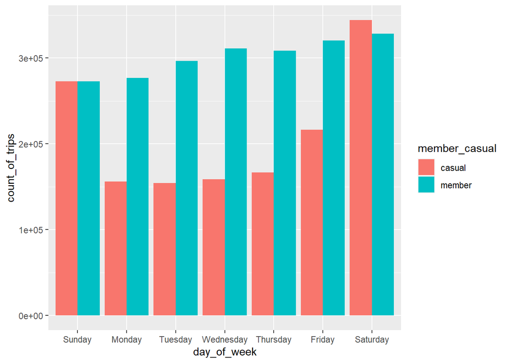

```r
all_trips_v2 %>% group_by(member_casual, day_of_week) %>%
  arrange(member_casual, day_of_week) %>% summarise(count_of_trips = n(), avg_trip_length = mean(ride_length)) %>%
  ggplot(aes(x=day_of_week, y=count_of_trips, fill=member_casual))+geom_col(position='dodge')
```

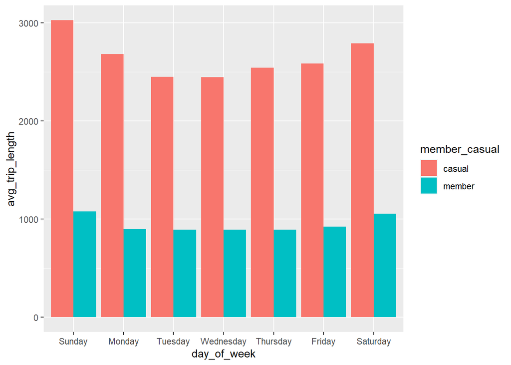

```r
all_trips_v2 %>% group_by(member_casual, day_of_week) %>%
  arrange(member_casual, day_of_week) %>% summarise(count_of_trips = n(), avg_trip_length = mean(ride_length)) %>%
  ggplot(aes(x=day_of_week, y=avg_trip_length, fill=member_casual))+geom_col(position='dodge')
```

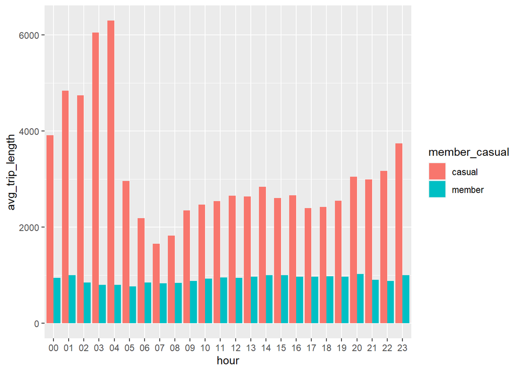

```r
all_trips_v2 %>% group_by(member_casual, hour) %>%
  arrange(member_casual, hour) %>% summarise(count_of_trips = n(), avg_trip_length = mean(ride_length)) %>%
  ggplot(aes(x=hour, y=avg_trip_length, fill=member_casual))+geom_col(position='dodge')
```

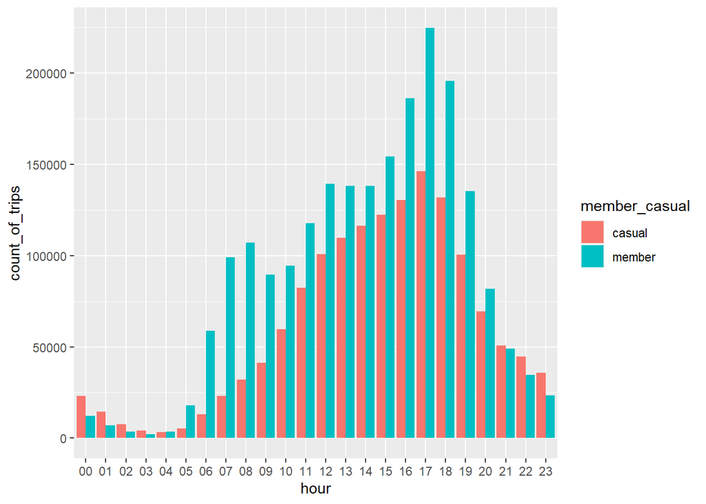

```r
all_trips_v2 %>% group_by(member_casual, hour) %>%
  arrange(member_casual, hour) %>% summarise(count_of_trips = n(), avg_trip_length = mean(ride_length)) %>%
  ggplot(aes(x=hour, y=count_of_trips, fill=member_casual))+geom_col(position='dodge')
```

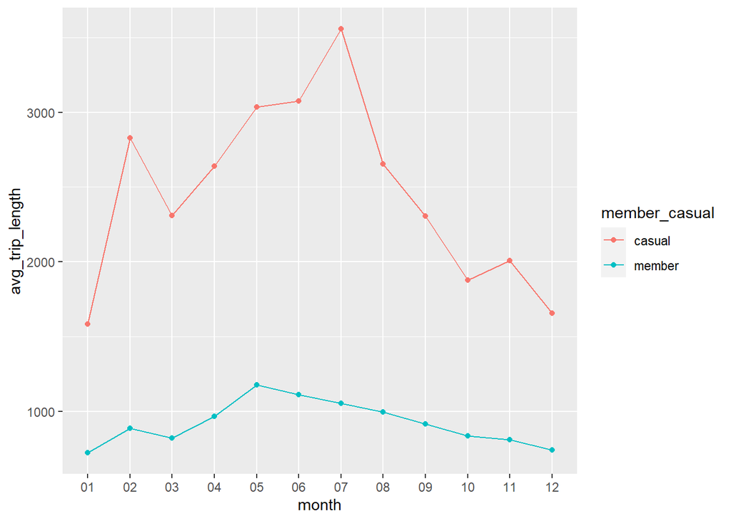

```r
all_trips_v2 %>% group_by(member_casual, month) %>%
  arrange(member_casual, month) %>% summarise(count_of_trips = n(), avg_trip_length = mean(ride_length)) %>%
  ggplot(aes(x=month, y=avg_trip_length, group=member_casual))+geom_line(aes(color=member_casual))+geom_point(aes(color=member_casual))
```